# Análisis estadístico de las condiciones ambientales y los factores de concurrencia en las distintas áreas del campus UTEC en el ciclo 2026-1

Author

S2-G6

Published

June 26, 2026

# I. Introducción

## I.1 Relevancia

El bienestar y el rendimiento académico de los estudiantes están vinculados con las condiciones físicas de los espacios donde desarrollan sus actividades. Factores como el ruido, la iluminación, la concurrencia y la disponibilidad de tomacorrientes influyen en la concentración, el avance de tareas y la comodidad. Este estudio busca generar evidencia cuantitativa y cualitativa que permita identificar patrones y orientar mejoras en la infraestructura del campus UTEC.

## I.2 Objetivos

### I.2.1 Objetivo general

Evaluar las condiciones ambientales en los espacios concurridos de la UTEC con el fin de identificar su impacto en el bienestar, uso, experiencia y desempeño académico de los estudiantes en el ciclo 2026-1.

### I.2.2 Objetivos específicos

**OE1:** Analizar la relación entre el nivel de ruido promedio (dB), la iluminación promedio (lux) y la fuente de luz según el propósito de la comunidad en el ambiente y el nivel de facilidad para estudiar en las áreas del campus UTEC en el ciclo 2026-1.

**OE2:** Comparar el nivel de comodidad y la frecuencia de uso del ambiente según la fuente principal de ruido y los tipos de distractores presentes en las áreas del campus UTEC en el ciclo 2026-1.

**OE3:** Evaluar cómo el número de personas presentes, número de tomacorrientes disponibles y los tipos de distractores presentes influyen en el avance de actividades académicas y nivel de facilidad para estudiar en las áreas del campus UTEC en el ciclo 2026-1.

# II. Contexto

## II.1 Población objetivo

La población objetivo está constituida por los espacios físicos del campus UTEC durante el ciclo 2026-1, considerando como unidad muestral cada combinación de ambiente-horario medida. Se contemplaron 5 ambientes distintos en 3 franjas horarias: mañana (9:00 am), tarde (1:00 pm) y noche (6:00 pm). Las encuestas de percepción se aplicaron a los estudiantes presentes en cada sesión de medición.

## II.2 Tipo de muestreo

Se utilizó un **muestreo por conveniencia estratificado** por ambiente y horario. Los 5 ambientes fueron preestablecidos y cada uno fue visitado en los 3 horarios definidos. Dentro de cada sesión, los 14 encuestados fueron seleccionados por disponibilidad entre los estudiantes presentes en el espacio al momento de la medición.

## II.3 Recolección de datos

Los datos se recolectaron mediante dos instrumentos digitales (Google Forms):

1. **Formulario 1 – Mediciones Técnicas e Infraestructura:** Llenado por el equipo de investigación. Registra variables cuantitativas (ruido en dB, iluminancia en lux) medidas con **phyphox**, y variables cualitativas observadas directamente (fuente de luz, fuente de ruido, propósito del ambiente, tipo de distractores, número de personas y tomacorrientes).
2. **Formulario 2 – Encuesta de Percepción Estudiantil:** Dirigido a 14 estudiantes por sesión. Evalúa variables ordinales mediante escalas del 1 al 5 (comodidad, facilidad para estudiar, avance académico) y frecuencia de uso (bajo/medio/alto).

Ambos formularios comparten una estructura filtro: Torre → Piso → Ambiente, vinculando cada encuesta con su medición técnica mediante un ID único.

**Protocolo de medición técnica:**

- **Ruido (dB):** App phyphox, módulo *Audio amplitude*. Calibración con offset 176. Medición continua 1 minuto. Promedio de la segunda columna exportada.
- **Iluminancia (lux):** App phyphox, módulo *Light*. Celular en el centro del espacio, cámara frontal hacia arriba. Medición continua 1 minuto. Promedio redondeado a 2 decimales.
- **Temperatura:** Termómetro físico en el centro del ambiente. Espera de 5 minutos para estabilización.

## II.4 Variables

```r
if (!require("tidyverse")) install.packages("tidyverse")
library(tidyverse)

tabla_variables <- tibble(
  Tipo = c(
    "Cualitativa nominal",
    "Cualitativa nominal",
    "Cualitativa nominal",
    "Cualitativa nominal",
    "Cualitativa ordinal",
    "Cualitativa ordinal",
    "Cualitativa ordinal",
    "Cualitativa ordinal",
    "Cuantitativa continua",
    "Cuantitativa continua",
    "Cuantitativa discreta",
    "Cuantitativa discreta"
  ),

  Variable = c(
    "Fuente principal de ruido",
    "Fuente de luz",
    "Propósito en la comunidad",
    "Tipo de distractores",
    "Nivel de facilidad para estudiar",
    "Avance de actividades curriculares",
    "Nivel de comodidad",
    "Frecuencia de uso del ambiente",
    "Nivel de presión sonora (dB)",
    "Nivel de iluminancia (lux)",
    "N° de personas presentes",
    "N° de tomacorrientes disponibles"
  ),

  Forma_medicion = c(
    "Observación directa (Tráfico / Charla / Obras / Pasillos)",
    "Observación directa (Natural / Artificial / Mixta)",
    "Observación directa (Estudio / Tránsito / Descanso / Socialización / Alimentación / Esparcimiento)",
    "Observación directa (Auditivos / Visuales / Tecnológicos / Olfativos)",
    "Encuesta escala 1–5",
    "Encuesta escala 1–5",
    "Encuesta escala 1–5",
    "Encuesta (1 = Bajo / 2 = Medio / 3 = Alto)",
    "phyphox, promedio de 1 minuto",
    "phyphox, promedio de 1 minuto",
    "Conteo directo",
    "Conteo directo"
  ),

  Objetivo_relacionado = c(
    "OE2",
    "OE1",
    "OE1",
    "OE2, OE3",
    "OE1, OE3",
    "OE3",
    "OE2",
    "OE2",
    "OE1",
    "OE1",
    "OE3",
    "OE3"
  )
)

tabla_variables
```

```
# A tibble: 12 × 4
   Tipo                  Variable            Forma_medicion Objetivo_relacionado
   <chr>                 <chr>               <chr>          <chr>
 1 Cualitativa nominal   Fuente principal d… Observación d… OE2
 2 Cualitativa nominal   Fuente de luz       Observación d… OE1
 3 Cualitativa nominal   Propósito en la co… Observación d… OE1
 4 Cualitativa nominal   Tipo de distractor… Observación d… OE2, OE3
 5 Cualitativa ordinal   Nivel de facilidad… Encuesta esca… OE1, OE3
 6 Cualitativa ordinal   Avance de activida… Encuesta esca… OE3
 7 Cualitativa ordinal   Nivel de comodidad  Encuesta esca… OE2
 8 Cualitativa ordinal   Frecuencia de uso … Encuesta (1 =… OE2
 9 Cuantitativa continua Nivel de presión s… phyphox, prom… OE1
10 Cuantitativa continua Nivel de iluminanc… phyphox, prom… OE1
11 Cuantitativa discreta N° de personas pre… Conteo directo OE3
12 Cuantitativa discreta N° de tomacorrient… Conteo directo OE3
```

```r
tabla_restricciones <- tibble(
  Variable = c(
    "Fuente principal de ruido",
    "Fuente de luz",
    "Propósito en la comunidad",
    "Tipo de distractores",
    "Nivel de facilidad para estudiar",
    "Avance de actividades curriculares",
    "Nivel de comodidad",
    "Frecuencia de uso del ambiente",
    "Nivel de presión sonora (dB)",
    "Nivel de iluminancia (lux)",
    "N° de personas presentes",
    "N° de tomacorrientes disponibles"
  ),

  Restricciones = c(
    "Tráfico / Charla / Obras / Pasillos",
    "Natural / Artificial / Mixta",
    "Estudio / Tránsito / Descanso / Socialización / Alimentación / Esparcimiento",
    "Auditivos / Visuales / Tecnológicos / Olfativos",
    "1 = Muy difícil | 2 = Difícil | 3 = Regular | 4 = Fácil | 5 = Muy fácil",
    "1 = Nada | 2 = Poco | 3 = Moderado | 4 = Bastante | 5 = Completo",
    "1 = Muy incómodo | 2 = Incómodo | 3 = Neutral | 4 = Cómodo | 5 = Muy cómodo",
    "1 = Bajo | 2 = Medio | 3 = Alto",
    "Rango: 0 - 140 dB",
    "Rango: 0 - 2000 lux",
    "Valores enteros positivos (1, 2, 3, ...)",
    "Valores enteros positivos (1, 2, 3, ...)"
  ),

  Medicion = c(
    "Observación directa",
    "Observación directa",
    "Observación directa",
    "Observación directa",
    "Escala Likert",
    "Escala Likert",
    "Escala Likert",
    "Escala Likert",
    "phyphox",
    "phyphox",
    "Conteo directo",
    "Conteo directo"
  )
)

tabla_restricciones
```

```
# A tibble: 12 × 3
   Variable                           Restricciones                     Medicion
   <chr>                              <chr>                             <chr>
 1 Fuente principal de ruido          Tráfico / Charla / Obras / Pasil… Observa…
 2 Fuente de luz                      Natural / Artificial / Mixta      Observa…
 3 Propósito en la comunidad          Estudio / Tránsito / Descanso / … Observa…
 4 Tipo de distractores               Auditivos / Visuales / Tecnológi… Observa…
 5 Nivel de facilidad para estudiar   1 = Muy difícil | 2 = Difícil | … Escala …
 6 Avance de actividades curriculares 1 = Nada | 2 = Poco | 3 = Modera… Escala …
 7 Nivel de comodidad                 1 = Muy incómodo | 2 = Incómodo … Escala …
 8 Frecuencia de uso del ambiente     1 = Bajo | 2 = Medio | 3 = Alto   Escala …
 9 Nivel de presión sonora (dB)       Rango: 0 - 140 dB                 phyphox
10 Nivel de iluminancia (lux)         Rango: 0 - 2000 lux               phyphox
11 N° de personas presentes           Valores enteros positivos (1, 2,… Conteo …
12 N° de tomacorrientes disponibles   Valores enteros positivos (1, 2,… Conteo …
```

## II.5 Limpieza

### Política de manejo de errores

```r
if (!require("readr")) install.packages("readr")
library(readr)

if (!require("dplyr")) install.packages("dplyr")
library(dplyr)

if (!require("tidyr")) install.packages("tidyr")
library(tidyr)

if (!require("ggplot2")) install.packages("ggplot2")
library(ggplot2)
```

### Lectura de datos

```r
DF_TablaMala_Encuestas <- read_csv("Condiciones ambientales en UTEC 2026-1 (respuestas) - Respuestas de formulario 1 (5).csv")
```

```
──────────────────────────────────────────────────────── Delimiter: "," chr
(4): Marca temporal, ¿Qué grupo lo/la está encuestando?, ¿En qué horari... dbl
(29): ¿En qué piso se encuentra?...5, ¿En qué piso se encuentra?...6, ¿E...
```

```r
DF_TablaMala_Mediciones <- read_csv("Condiciones ambientales en UTEC 2026-1 - Condiciones del lugar (Respuestas) - Respuestas de formulario 1 (1).csv")
```

```
──────────────────────────────────────────────────────── Delimiter: "," chr
(14): Marca temporal, Grupo, ¿En qué horario está llenando el formulario... dbl
(22): ¿En qué piso se encuentra?...5, ¿En qué piso se encuentra?...6, ¿E...
```

### Recostruccion de tablas

```r
# La función `contar_validos` detecta las columnas con el mismo nombre base y cuenta cuántas tienen dato real por fila.

contar_validos <- function(data, nombre_base) {
  cols <- names(data)[startsWith(names(data), nombre_base)]
  rowSums(!is.na(data[, cols]) & data[, cols] != "")
}
```

```r
# piso
all(contar_validos(DF_TablaMala_Encuestas, "¿En qué piso se encuentra?") == 1)
```

```
[1] TRUE
```

```r
all(contar_validos(DF_TablaMala_Mediciones, "¿En qué piso se encuentra?") == 1)
```

```
[1] TRUE
```

```r
# ambiente
all(contar_validos(DF_TablaMala_Encuestas,  "¿En qué ambiente se encuentra?") == 1)
```

```
[1] TRUE
```

```r
all(contar_validos(DF_TablaMala_Mediciones, "¿En qué ambiente se encuentra?") == 1)
```

```
[1] TRUE
```

```r
# extrae el único valor no vacío entre las columnas duplicadas por fila. Si no encuentra ninguno devuelve NA

unificar_columnas <- function(data, nombre_base) {

  cols <- names(data)[startsWith(names(data), nombre_base)]

  apply(data[, cols], 1, function(fila) {
    valores <- fila[!is.na(fila) & fila != ""]
    if (length(valores) > 0) valores[1] else NA
  })
}
```

```r
cols_piso_enc <- names(DF_TablaMala_Encuestas)[startsWith(names(DF_TablaMala_Encuestas), "¿En qué piso se encuentra?")]
cols_ambiente_enc <- names(DF_TablaMala_Encuestas)[startsWith(names(DF_TablaMala_Encuestas), "¿En qué ambiente se encuentra?")]

cols_piso_med <- names(DF_TablaMala_Mediciones)[startsWith(names(DF_TablaMala_Mediciones), "¿En qué piso se encuentra?")]
cols_ambiente_med <- names(DF_TablaMala_Mediciones)[startsWith(names(DF_TablaMala_Mediciones), "¿En qué ambiente se encuentra?")]
```

```r
DF_TablaBuena_Encuestas <- DF_TablaMala_Encuestas %>%
  mutate(
    Piso = unificar_columnas(., "¿En qué piso se encuentra?"),
    Ambiente = unificar_columnas(., "¿En qué ambiente se encuentra?"),

    ID = paste0(
      Piso,
      `¿En qué torre se encuentra?`,
      Ambiente,
      "-",
      format(as.POSIXct(`Marca temporal`, format = "%d/%m/%Y %H:%M:%S"), "%d%m"),
      "-",
      gsub("[^0-9]", "", `¿En qué horario está llenando el formulario?`)
    )
  ) %>%
  select(
    -all_of(cols_piso_enc),
    -all_of(cols_ambiente_enc)
  ) %>%
  relocate(
    ID,
    `Marca temporal`,
    `¿Qué grupo lo/la está encuestando?`,
    `¿En qué horario está llenando el formulario?`,
    `¿En qué torre se encuentra?`,
    Piso,
    Ambiente
  )

DF_TablaBuena_Mediciones <- DF_TablaMala_Mediciones %>%
  mutate(
    Piso = unificar_columnas(., "¿En qué piso se encuentra?"),
    Ambiente = unificar_columnas(., "¿En qué ambiente se encuentra?"),

    ID = paste0(
      Piso,
      `¿En qué torre se encuentra?`,
      Ambiente,
      "-",
      format(as.POSIXct(`Marca temporal`, format = "%d/%m/%Y %H:%M:%S"), "%d%m"),
      "-",
      gsub("[^0-9]", "", `¿En qué horario está llenando el formulario?`)
    )
  ) %>%
  select(
    -all_of(cols_piso_med),
    -all_of(cols_ambiente_med)
  ) %>%
  relocate(
    ID,
    `Marca temporal`,
    Grupo,
    `¿En qué horario está llenando el formulario?`,
    `¿En qué torre se encuentra?`,
    Piso,
    Ambiente
  )
```

### Conjunto de variables

```r
DF_Grupo6_Encuestas <- DF_TablaBuena_Encuestas %>%
  select(
    ID,
    `Marca temporal`,
    `¿Qué grupo lo/la está encuestando?`,
    `¿En qué horario está llenando el formulario?`,
    `¿En qué torre se encuentra?`,
    Piso,
    Ambiente,
    `Nivel de comodidad`,
    `Frecuencia de uso del ambiente`,
    `Avance de actividades curriculares`,
    `Nivel de facilidad para estudiar en el ambiente`
  )

DF_Grupo6_Mediciones <- DF_TablaBuena_Mediciones %>%
  select(
    ID,
    `Marca temporal`,
    Grupo,
    `¿En qué horario está llenando el formulario?`,
    `¿En qué torre se encuentra?`,
    Piso,
    Ambiente,
    `Nivel de presión sonora (dB)`,
    `Nivel de iluminancia`,
    `Fuente de luz`,
    `Fuente principal de ruido`,
    `N° de personas presentes`,
    `N° de tomacorrientes disponibles`,
    `Cantidad de luminarias (focos) funcionando`,
    `Tipo de distractores no relacionados con su propósito`,
    `Propósito en la comunidad`
  )
```

### Radiografia

Estado inicial de cada variable

```r
radiografia <- function(df) {
  data.frame(
    Porcentaje_NA = sapply(df, function(x) round(mean(is.na(x)) * 100, 2)),
    Porcentaje_Cero = sapply(df, function(x) round(mean(x == 0, na.rm = TRUE) * 100, 2)),
    Valores_Unicos = sapply(df, function(x) length(unique(na.omit(x))))
  )
}

radiografia(DF_Grupo6_Encuestas)
```

```
                                                Porcentaje_NA Porcentaje_Cero
ID                                                        0.0               0
Marca temporal                                            0.0               0
¿Qué grupo lo/la está encuestando?                        0.0               0
¿En qué horario está llenando el formulario?              0.1               0
¿En qué torre se encuentra?                               0.0               0
Piso                                                      0.0               0
Ambiente                                                  0.0               0
Nivel de comodidad                                        0.0               0
Frecuencia de uso del ambiente                            0.0               0
Avance de actividades curriculares                        0.0               0
Nivel de facilidad para estudiar en el ambiente           0.0               0
                                                Valores_Unicos
ID                                                         371
Marca temporal                                            1966
¿Qué grupo lo/la está encuestando?                          11
¿En qué horario está llenando el formulario?                 5
¿En qué torre se encuentra?                                  3
Piso                                                        11
Ambiente                                                     7
Nivel de comodidad                                           5
Frecuencia de uso del ambiente                               3
Avance de actividades curriculares                           5
Nivel de facilidad para estudiar en el ambiente              5
```

```r
radiografia(DF_Grupo6_Mediciones)
```

```
                                                      Porcentaje_NA
ID                                                             0.00
Marca temporal                                                 0.00
Grupo                                                          0.00
¿En qué horario está llenando el formulario?                   0.00
¿En qué torre se encuentra?                                    0.00
Piso                                                           0.00
Ambiente                                                       0.00
Nivel de presión sonora (dB)                                   0.00
Nivel de iluminancia                                           0.00
Fuente de luz                                                  0.29
Fuente principal de ruido                                      0.00
N° de personas presentes                                       0.00
N° de tomacorrientes disponibles                               0.00
Cantidad de luminarias (focos) funcionando                     0.00
Tipo de distractores no relacionados con su propósito          0.00
Propósito en la comunidad                                      0.29
                                                      Porcentaje_Cero
ID                                                               0.00
Marca temporal                                                   0.00
Grupo                                                            0.00
¿En qué horario está llenando el formulario?                     0.00
¿En qué torre se encuentra?                                      0.00
Piso                                                             0.00
Ambiente                                                         0.00
Nivel de presión sonora (dB)                                     0.00
Nivel de iluminancia                                             0.00
Fuente de luz                                                    0.00
Fuente principal de ruido                                        0.00
N° de personas presentes                                         1.18
N° de tomacorrientes disponibles                                 7.65
Cantidad de luminarias (focos) funcionando                      36.76
Tipo de distractores no relacionados con su propósito            0.00
Propósito en la comunidad                                        0.00
                                                      Valores_Unicos
ID                                                               248
Marca temporal                                                   339
Grupo                                                              9
¿En qué horario está llenando el formulario?                       3
¿En qué torre se encuentra?                                        3
Piso                                                              11
Ambiente                                                           6
Nivel de presión sonora (dB)                                     306
Nivel de iluminancia                                             309
Fuente de luz                                                      3
Fuente principal de ruido                                          4
N° de personas presentes                                          47
N° de tomacorrientes disponibles                                  32
Cantidad de luminarias (focos) funcionando                        29
Tipo de distractores no relacionados con su propósito              4
Propósito en la comunidad                                          6
```

### Normalización de formatos

Se unificaron registros equivalentes en horarios. En variables numéricas se corrigieron errores de formato

```r
DF_Grupo6_Encuestas <- DF_Grupo6_Encuestas %>%
  mutate(
    `¿En qué horario está llenando el formulario?` = case_when(
      `¿En qué horario está llenando el formulario?` %in% c("09", "9") ~ "9",
      `¿En qué horario está llenando el formulario?` == "13" ~ "13",
      `¿En qué horario está llenando el formulario?` == "18" ~ "18",
      TRUE ~ NA_character_
    )
  )

DF_Grupo6_Mediciones <- DF_Grupo6_Mediciones %>%
  mutate(
    `Nivel de presión sonora (dB)` = (as.numeric(
      gsub(",", ".", gsub("dB", "", `Nivel de presión sonora (dB)`))
    )),

    `Nivel de iluminancia` = (as.numeric(
      gsub(",", ".", `Nivel de iluminancia`)
    )),

    `Cantidad de luminarias (focos) funcionando` = (as.numeric(
      `Cantidad de luminarias (focos) funcionando`
    )),

    `N° de tomacorrientes disponibles` = (as.numeric(
      `N° de tomacorrientes disponibles`
    ))
  )
```

### Aplicación de criterios y conversión de tipos

```r
DF_Grupo6_Encuestas <- DF_Grupo6_Encuestas %>%
  # Ordinales
  mutate(
    `Nivel de comodidad` = factor(`Nivel de comodidad`,
                                   levels = c(1, 2, 3, 4, 5),
                                   ordered = TRUE),

    `Frecuencia de uso del ambiente` = factor(`Frecuencia de uso del ambiente`,
                                               levels = c(1, 2, 3),
                                               ordered = TRUE),

    `Avance de actividades curriculares` = factor(`Avance de actividades curriculares`,
                                                   levels = c(1, 2, 3, 4, 5),
                                                   ordered = TRUE),

    `Nivel de facilidad para estudiar en el ambiente` = factor(`Nivel de facilidad para estudiar en el ambiente`,
                                                                levels = c(1, 2, 3, 4, 5),
                                                                ordered = TRUE)
  )

DF_Grupo6_Mediciones <- DF_Grupo6_Mediciones %>%
  mutate(
    # Continuas
    `Nivel de presión sonora (dB)` = ifelse(
      `Nivel de presión sonora (dB)` >= 0 & `Nivel de presión sonora (dB)` <= 170,
      `Nivel de presión sonora (dB)`, NA_real_
    ),

    `Nivel de iluminancia` = ifelse(
      `Nivel de iluminancia` >= 0 & `Nivel de iluminancia` <= 2000,
      `Nivel de iluminancia`, NA_real_
    ),

    # Discretas
    `Cantidad de luminarias (focos) funcionando` = as.integer(`Cantidad de luminarias (focos) funcionando`),
    `Cantidad de luminarias (focos) funcionando` = ifelse(
      `Cantidad de luminarias (focos) funcionando` >= 1,
      `Cantidad de luminarias (focos) funcionando`, NA_integer_
    ),

    `N° de personas presentes` = as.integer(`N° de personas presentes`),
    `N° de personas presentes` = ifelse(
      `N° de personas presentes` >= 1,
      `N° de personas presentes`, NA_integer_
    ),

    `N° de tomacorrientes disponibles` = as.integer(
      `N° de tomacorrientes disponibles`
    ),
    `N° de tomacorrientes disponibles` = ifelse(
      `N° de tomacorrientes disponibles` >= 1,
      `N° de tomacorrientes disponibles`, NA_integer_
    ),

    # Nominales
    `Fuente de luz` = factor(`Fuente de luz`,
                              levels = c("Natural", "Artificial", "Mixta")),

    `Fuente principal de ruido` = factor(`Fuente principal de ruido`,
                                          levels = c("Tráfico vehicular", "Charla de estudiantes",
                                                     "Obras de construcción", "Pasillos")),

    `Tipo de distractores no relacionados con su propósito` = factor(
      `Tipo de distractores no relacionados con su propósito`,
      levels = c("Auditivos", "Visuales", "Tecnológicos", "Olfativos")
    ),

    `Propósito en la comunidad` = factor(`Propósito en la comunidad`,
                                          levels = c("Estudio", "Tránsito", "Descanso",
                                                     "Socialización", "Alimentación", "Esparcimiento"))
  )
```

### Gestión de valores atípicos

```r
detectar_outliers <- function(x) {
  Q1  <- quantile(x, 0.25, na.rm = TRUE)
  Q3  <- quantile(x, 0.75, na.rm = TRUE)
  IQR <- Q3 - Q1
  x < (Q1 - 1.5 * IQR) | x > (Q3 + 1.5 * IQR)
}

cat("Presión sonora:", sum(detectar_outliers(DF_Grupo6_Mediciones$`Nivel de presión sonora (dB)`), na.rm = TRUE), "outliers\n")
```

```
Presión sonora: 0 outliers
```

```r
cat("Iluminancia:", sum(detectar_outliers(DF_Grupo6_Mediciones$`Nivel de iluminancia`), na.rm = TRUE), "outliers\n")
```

```
Iluminancia: 29 outliers
```

```r
cat("Personas:", sum(detectar_outliers(DF_Grupo6_Mediciones$`N° de personas presentes`), na.rm = TRUE), "outliers\n")
```

```
Personas: 22 outliers
```

```r
cat("Mobiliario:", sum(detectar_outliers(DF_Grupo6_Mediciones$`Número de mobiliario disponible: Se toma el recurso principal o el paquete del recurso principal (cubículo (silla + mesa))`), na.rm = TRUE), "outliers\n")
```

```
Mobiliario: 0 outliers
```

```r
cat("Luminarias:", sum(detectar_outliers(DF_Grupo6_Mediciones$`Cantidad de luminarias (focos) funcionando`), na.rm = TRUE), "outliers\n")
```

```
Luminarias: 8 outliers
```

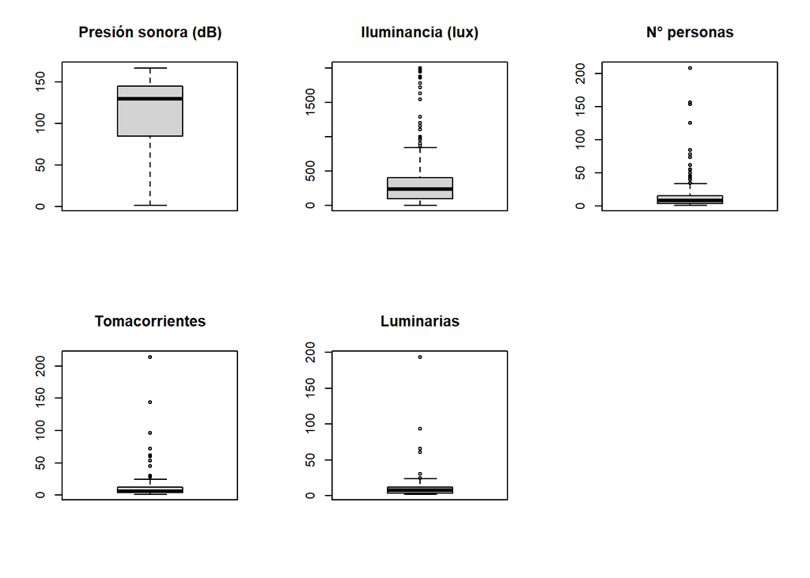

```r
par(mfrow = c(2, 3))
boxplot(DF_Grupo6_Mediciones$`Nivel de presión sonora (dB)`, main = "Presión sonora (dB)")
boxplot(DF_Grupo6_Mediciones$`Nivel de iluminancia`, main = "Iluminancia (lux)")
boxplot(DF_Grupo6_Mediciones$`N° de personas presentes`, main = "N° personas")
boxplot(DF_Grupo6_Mediciones$`N° de tomacorrientes disponibles`, main = "Tomacorrientes")
boxplot(DF_Grupo6_Mediciones$`Cantidad de luminarias (focos) funcionando`, main = "Luminarias")
par(mfrow = c(1, 1))
```

```r
DF_Grupo6_Mediciones <- DF_Grupo6_Mediciones %>%
  mutate(
    `Nivel de presión sonora (dB)` = ifelse(
      `Nivel de presión sonora (dB)` < 30,
      NA_real_,
      `Nivel de presión sonora (dB)`
    )
  )
```

Para el nivel de presión sonora se convirtieron a NA los valores inferiores a 30 dB, físicamente inconsistentes

### Análisis de variabilidad

```r
# nominales
DF_Grupo6_Mediciones %>% count(`Fuente de luz`) %>% mutate(Porcentaje = n / sum(n) * 100)
```

```
# A tibble: 4 × 3
  `Fuente de luz`     n Porcentaje
  <fct>           <int>      <dbl>
1 Natural           127     37.4
2 Artificial        115     33.8
3 Mixta              97     28.5
4 <NA>                1      0.294
```

```r
DF_Grupo6_Mediciones %>% count(`Fuente principal de ruido`) %>% mutate(Porcentaje = n / sum(n) * 100)
```

```
# A tibble: 4 × 3
  `Fuente principal de ruido`     n Porcentaje
  <fct>                       <int>      <dbl>
1 Tráfico vehicular              90      26.5
2 Charla de estudiantes         158      46.5
3 Obras de construcción           9       2.65
4 Pasillos                       83      24.4
```

```r
DF_Grupo6_Mediciones %>% count(`Tipo de distractores no relacionados con su propósito`) %>% mutate(Porcentaje = n / sum(n) * 100)
```

```
# A tibble: 4 × 3
  `Tipo de distractores no relacionados con su propósito`     n Porcentaje
  <fct>                                                   <int>      <dbl>
1 Auditivos                                                 168     49.4
2 Visuales                                                   75     22.1
3 Tecnológicos                                               95     27.9
4 Olfativos                                                   2      0.588
```

```r
DF_Grupo6_Mediciones %>% count(`Propósito en la comunidad`) %>% mutate(Porcentaje = n / sum(n) * 100)
```

```
# A tibble: 7 × 3
  `Propósito en la comunidad`     n Porcentaje
  <fct>                       <int>      <dbl>
1 Estudio                       119     35
2 Tránsito                       62     18.2
3 Descanso                       53     15.6
4 Socialización                  39     11.5
5 Alimentación                   27      7.94
6 Esparcimiento                  39     11.5
7 <NA>                            1      0.294
```

```r
# ordinales
DF_Grupo6_Encuestas %>% count(`Nivel de comodidad`) %>% mutate(Porcentaje = n / sum(n) * 100)
```

```
# A tibble: 5 × 3
  `Nivel de comodidad`     n Porcentaje
  <ord>                <int>      <dbl>
1 1                       88       4.38
2 2                      261      13.0
3 3                      760      37.8
4 4                      638      31.8
5 5                      261      13.0
```

```r
DF_Grupo6_Encuestas %>% count(`Frecuencia de uso del ambiente`) %>% mutate(Porcentaje = n / sum(n) * 100)
```

```
# A tibble: 3 × 3
  `Frecuencia de uso del ambiente`     n Porcentaje
  <ord>                            <int>      <dbl>
1 1                                  423       21.1
2 2                                  983       49.0
3 3                                  602       30.0
```

```r
DF_Grupo6_Encuestas %>% count(`Avance de actividades curriculares`) %>% mutate(Porcentaje = n / sum(n) * 100)
```

```
# A tibble: 5 × 3
  `Avance de actividades curriculares`     n Porcentaje
  <ord>                                <int>      <dbl>
1 1                                      159       7.92
2 2                                      292      14.5
3 3                                      709      35.3
4 4                                      604      30.1
5 5                                      244      12.2
```

```r
DF_Grupo6_Encuestas %>% count(`Nivel de facilidad para estudiar en el ambiente`) %>% mutate(Porcentaje = n / sum(n) * 100)
```

```
# A tibble: 5 × 3
  `Nivel de facilidad para estudiar en el ambiente`     n Porcentaje
  <ord>                                             <int>      <dbl>
1 1                                                   202       10.1
2 2                                                   261       13.0
3 3                                                   723       36.0
4 4                                                   554       27.6
5 5                                                   268       13.3
```

```r
# Cuantitativas
cv <- function(x) (sd(x, na.rm = TRUE) / mean(x, na.rm = TRUE))

data.frame(
  Variable = c("Presión sonora", "Iluminancia", "Personas", "Tomacorrientes", "Luminarias"),
  CV = c(
    cv(DF_Grupo6_Mediciones$`Nivel de presión sonora (dB)`),
    cv(DF_Grupo6_Mediciones$`Nivel de iluminancia`),
    cv(DF_Grupo6_Mediciones$`N° de personas presentes`),
    cv(DF_Grupo6_Mediciones$`N° de tomacorrientes disponibles`),
    cv(DF_Grupo6_Mediciones$`Cantidad de luminarias (focos) funcionando`)
  )
)
```

```
        Variable        CV
1 Presión sonora 0.3160809
2    Iluminancia 1.2037979
3       Personas 1.5125982
4 Tomacorrientes 1.5849888
5     Luminarias 1.7873706
```

### Política de manejo de datos faltantes

#### Gestión de nulos

```r
radiografia(DF_Grupo6_Encuestas)
```

```
                                                Porcentaje_NA Porcentaje_Cero
ID                                                       0.00               0
Marca temporal                                           0.00               0
¿Qué grupo lo/la está encuestando?                       0.00               0
¿En qué horario está llenando el formulario?             0.15               0
¿En qué torre se encuentra?                              0.00               0
Piso                                                     0.00               0
Ambiente                                                 0.00               0
Nivel de comodidad                                       0.00               0
Frecuencia de uso del ambiente                           0.00               0
Avance de actividades curriculares                       0.00               0
Nivel de facilidad para estudiar en el ambiente          0.00               0
                                                Valores_Unicos
ID                                                         371
Marca temporal                                            1966
¿Qué grupo lo/la está encuestando?                          11
¿En qué horario está llenando el formulario?                 3
¿En qué torre se encuentra?                                  3
Piso                                                        11
Ambiente                                                     7
Nivel de comodidad                                           5
Frecuencia de uso del ambiente                               3
Avance de actividades curriculares                           5
Nivel de facilidad para estudiar en el ambiente              5
```

```r
radiografia(DF_Grupo6_Mediciones)
```

```
                                                      Porcentaje_NA
ID                                                             0.00
Marca temporal                                                 0.00
Grupo                                                          0.00
¿En qué horario está llenando el formulario?                   0.00
¿En qué torre se encuentra?                                    0.00
Piso                                                           0.00
Ambiente                                                       0.00
Nivel de presión sonora (dB)                                   8.82
Nivel de iluminancia                                           6.47
Fuente de luz                                                  0.29
Fuente principal de ruido                                      0.00
N° de personas presentes                                       1.18
N° de tomacorrientes disponibles                               7.65
Cantidad de luminarias (focos) funcionando                    37.06
Tipo de distractores no relacionados con su propósito          0.00
Propósito en la comunidad                                      0.29
                                                      Porcentaje_Cero
ID                                                                  0
Marca temporal                                                      0
Grupo                                                               0
¿En qué horario está llenando el formulario?                        0
¿En qué torre se encuentra?                                         0
Piso                                                                0
Ambiente                                                            0
Nivel de presión sonora (dB)                                        0
Nivel de iluminancia                                                0
Fuente de luz                                                       0
Fuente principal de ruido                                           0
N° de personas presentes                                            0
N° de tomacorrientes disponibles                                    0
Cantidad de luminarias (focos) funcionando                          0
Tipo de distractores no relacionados con su propósito               0
Propósito en la comunidad                                           0
                                                      Valores_Unicos
ID                                                               248
Marca temporal                                                   339
Grupo                                                              9
¿En qué horario está llenando el formulario?                       3
¿En qué torre se encuentra?                                        3
Piso                                                              11
Ambiente                                                           6
Nivel de presión sonora (dB)                                     278
Nivel de iluminancia                                             291
Fuente de luz                                                      3
Fuente principal de ruido                                          4
N° de personas presentes                                          46
N° de tomacorrientes disponibles                                  31
Cantidad de luminarias (focos) funcionando                        26
Tipo de distractores no relacionados con su propósito              4
Propósito en la comunidad                                          6
```

```r
# impacto del na.omit
nrow(DF_Grupo6_Encuestas)
```

```
[1] 2008
```

```r
nrow(DF_Grupo6_Mediciones)
```

```
[1] 340
```

```r
DF_Grupo6_Encuestas_Limpio <- na.omit(DF_Grupo6_Encuestas)
DF_Grupo6_Mediciones_Limpio <- na.omit(DF_Grupo6_Mediciones)

nrow(DF_Grupo6_Encuestas_Limpio)
```

```
[1] 2005
```

```r
nrow(DF_Grupo6_Mediciones_Limpio)
```

```
[1] 175
```

```r
radiografia(DF_Grupo6_Encuestas_Limpio)
```

```
                                                Porcentaje_NA Porcentaje_Cero
ID                                                          0               0
Marca temporal                                              0               0
¿Qué grupo lo/la está encuestando?                          0               0
¿En qué horario está llenando el formulario?                0               0
¿En qué torre se encuentra?                                 0               0
Piso                                                        0               0
Ambiente                                                    0               0
Nivel de comodidad                                          0               0
Frecuencia de uso del ambiente                              0               0
Avance de actividades curriculares                          0               0
Nivel de facilidad para estudiar en el ambiente             0               0
                                                Valores_Unicos
ID                                                         368
Marca temporal                                            1963
¿Qué grupo lo/la está encuestando?                          11
¿En qué horario está llenando el formulario?                 3
¿En qué torre se encuentra?                                  3
Piso                                                        11
Ambiente                                                     7
Nivel de comodidad                                           5
Frecuencia de uso del ambiente                               3
Avance de actividades curriculares                           5
Nivel de facilidad para estudiar en el ambiente              5
```

```r
radiografia(DF_Grupo6_Mediciones_Limpio)
```

```
                                                      Porcentaje_NA
ID                                                                0
Marca temporal                                                    0
Grupo                                                             0
¿En qué horario está llenando el formulario?                      0
¿En qué torre se encuentra?                                       0
Piso                                                              0
Ambiente                                                          0
Nivel de presión sonora (dB)                                      0
Nivel de iluminancia                                              0
Fuente de luz                                                     0
Fuente principal de ruido                                         0
N° de personas presentes                                          0
N° de tomacorrientes disponibles                                  0
Cantidad de luminarias (focos) funcionando                        0
Tipo de distractores no relacionados con su propósito             0
Propósito en la comunidad                                         0
                                                      Porcentaje_Cero
ID                                                                  0
Marca temporal                                                      0
Grupo                                                               0
¿En qué horario está llenando el formulario?                        0
¿En qué torre se encuentra?                                         0
Piso                                                                0
Ambiente                                                            0
Nivel de presión sonora (dB)                                        0
Nivel de iluminancia                                                0
Fuente de luz                                                       0
Fuente principal de ruido                                           0
N° de personas presentes                                            0
N° de tomacorrientes disponibles                                    0
Cantidad de luminarias (focos) funcionando                          0
Tipo de distractores no relacionados con su propósito               0
Propósito en la comunidad                                           0
                                                      Valores_Unicos
ID                                                               137
Marca temporal                                                   174
Grupo                                                              9
¿En qué horario está llenando el formulario?                       3
¿En qué torre se encuentra?                                        3
Piso                                                              11
Ambiente                                                           6
Nivel de presión sonora (dB)                                     162
Nivel de iluminancia                                             167
Fuente de luz                                                      3
Fuente principal de ruido                                          4
N° de personas presentes                                          43
N° de tomacorrientes disponibles                                  29
Cantidad de luminarias (focos) funcionando                        25
Tipo de distractores no relacionados con su propósito              4
Propósito en la comunidad                                          6
```

```r
# quitamos Cantidad de luminarias por alto porcentaje de NA
DF_Grupo6_Mediciones_Limpio <- DF_Grupo6_Mediciones %>%
  select(-`Cantidad de luminarias (focos) funcionando`) %>%
  na.omit()

nrow(DF_Grupo6_Mediciones_Limpio)
```

```
[1] 270
```

```r
radiografia(DF_Grupo6_Mediciones_Limpio)
```

```
                                                      Porcentaje_NA
ID                                                                0
Marca temporal                                                    0
Grupo                                                             0
¿En qué horario está llenando el formulario?                      0
¿En qué torre se encuentra?                                       0
Piso                                                              0
Ambiente                                                          0
Nivel de presión sonora (dB)                                      0
Nivel de iluminancia                                              0
Fuente de luz                                                     0
Fuente principal de ruido                                         0
N° de personas presentes                                          0
N° de tomacorrientes disponibles                                  0
Tipo de distractores no relacionados con su propósito             0
Propósito en la comunidad                                         0
                                                      Porcentaje_Cero
ID                                                                  0
Marca temporal                                                      0
Grupo                                                               0
¿En qué horario está llenando el formulario?                        0
¿En qué torre se encuentra?                                         0
Piso                                                                0
Ambiente                                                            0
Nivel de presión sonora (dB)                                        0
Nivel de iluminancia                                                0
Fuente de luz                                                       0
Fuente principal de ruido                                           0
N° de personas presentes                                            0
N° de tomacorrientes disponibles                                    0
Tipo de distractores no relacionados con su propósito               0
Propósito en la comunidad                                           0
                                                      Valores_Unicos
ID                                                               196
Marca temporal                                                   269
Grupo                                                              9
¿En qué horario está llenando el formulario?                       3
¿En qué torre se encuentra?                                        3
Piso                                                              11
Ambiente                                                           6
Nivel de presión sonora (dB)                                     245
Nivel de iluminancia                                             255
Fuente de luz                                                      3
Fuente principal de ruido                                          4
N° de personas presentes                                          44
N° de tomacorrientes disponibles                                  30
Tipo de distractores no relacionados con su propósito              4
Propósito en la comunidad                                          6
```

```r
# solo nos quedamos con observaciones que tengan medición Y encuesta
DF_Final <- inner_join(DF_Grupo6_Mediciones_Limpio,
                       DF_Grupo6_Encuestas_Limpio,
                       by = "ID") %>%
  select(
    ID,
    `Marca temporal.x`,
    Grupo,
    `¿En qué horario está llenando el formulario?.x`,
    `¿En qué torre se encuentra?.x`,
    `Piso.x`,
    `Ambiente.x`,
    `Nivel de presión sonora (dB)`,
    `Nivel de iluminancia`,
    `Fuente de luz`,
    `Fuente principal de ruido`,
    `N° de personas presentes`,
    `N° de tomacorrientes disponibles`,
    `Tipo de distractores no relacionados con su propósito`,
    `Propósito en la comunidad`,
    `Nivel de comodidad`,
    `Frecuencia de uso del ambiente`,
    `Avance de actividades curriculares`,
    `Nivel de facilidad para estudiar en el ambiente`
  ) %>%
  rename(
    `Marca temporal` = `Marca temporal.x`,
    `¿En qué horario está llenando el formulario?` = `¿En qué horario está llenando el formulario?.x`,
    `¿En qué torre se encuentra?` = `¿En qué torre se encuentra?.x`,
    Piso = `Piso.x`,
    Ambiente = `Ambiente.x`
  )
nrow(DF_Final)
```

```
[1] 1669
```

```r
DF_Final_grupo6 <- DF_Final %>% filter(Grupo == "Grupo 6")
nrow(DF_Final_grupo6)
```

```
[1] 231
```

# III. Análisis descriptivo

Se analizan en detalle las variables más relevantes para los tres objetivos específicos. Para las variables cuantitativas se reportan descriptores de posición y dispersión; para las ordinales, moda, mediana y cuartiles; para las nominales, frecuencias y porcentajes.

## III.1 Análisis univariado

### Variable 1: Nivel de presión sonora (dB) Cuantitativa continua

```r
Q1 <- quantile(DF_Final$`Nivel de presión sonora (dB)`, 0.25, na.rm = TRUE)
Q3 <- quantile(DF_Final$`Nivel de presión sonora (dB)`, 0.75, na.rm = TRUE)

tabla_presionsonora <- data.frame(
  Descriptor = c(
    "Media", "Mediana", "Desviación estándar",
    "Coeficiente de variación", "Q1", "Q3",
    "Rango intercuartílico (IQR)", "Mínimo", "Máximo"
  ),
  Valor = c(
    round(mean(DF_Final$`Nivel de presión sonora (dB)`, na.rm = TRUE), 2),
    round(median(DF_Final$`Nivel de presión sonora (dB)`, na.rm = TRUE), 2),
    round(sd(DF_Final$`Nivel de presión sonora (dB)`, na.rm = TRUE), 2),
    round(sd(DF_Final$`Nivel de presión sonora (dB)`, na.rm = TRUE) /
            mean(DF_Final$`Nivel de presión sonora (dB)`, na.rm = TRUE), 2),
    round(Q1, 2),
    round(Q3, 2),
    round(Q3 - Q1, 2),
    round(min(DF_Final$`Nivel de presión sonora (dB)`, na.rm = TRUE), 2),
    round(max(DF_Final$`Nivel de presión sonora (dB)`, na.rm = TRUE), 2)
  )
)

tabla_presionsonora
```

```
                   Descriptor  Valor
1                       Media 115.04
2                     Mediana 128.29
3         Desviación estándar  37.06
4    Coeficiente de variación   0.32
5                          Q1  86.78
6                          Q3 144.16
7 Rango intercuartílico (IQR)  57.38
8                      Mínimo  30.00
9                      Máximo 166.60
```

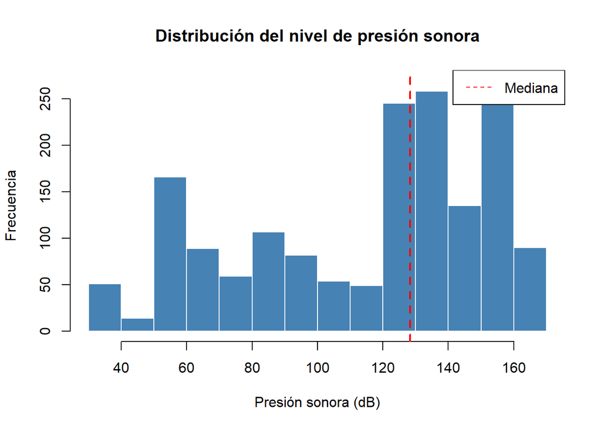

```r
# Histograma
hist(
  na.omit(DF_Final$`Nivel de presión sonora (dB)`),
  main= "Distribución del nivel de presión sonora",
  xlab= "Presión sonora (dB)",
  ylab = "Frecuencia",
  col = "steelblue",
  border = "white"
)
abline(v = median(na.omit(DF_Final$`Nivel de presión sonora (dB)`)),col = "red", lty = 2, lwd = 2)
legend("topright", legend = "Mediana", col = "red", lty = 2)
```

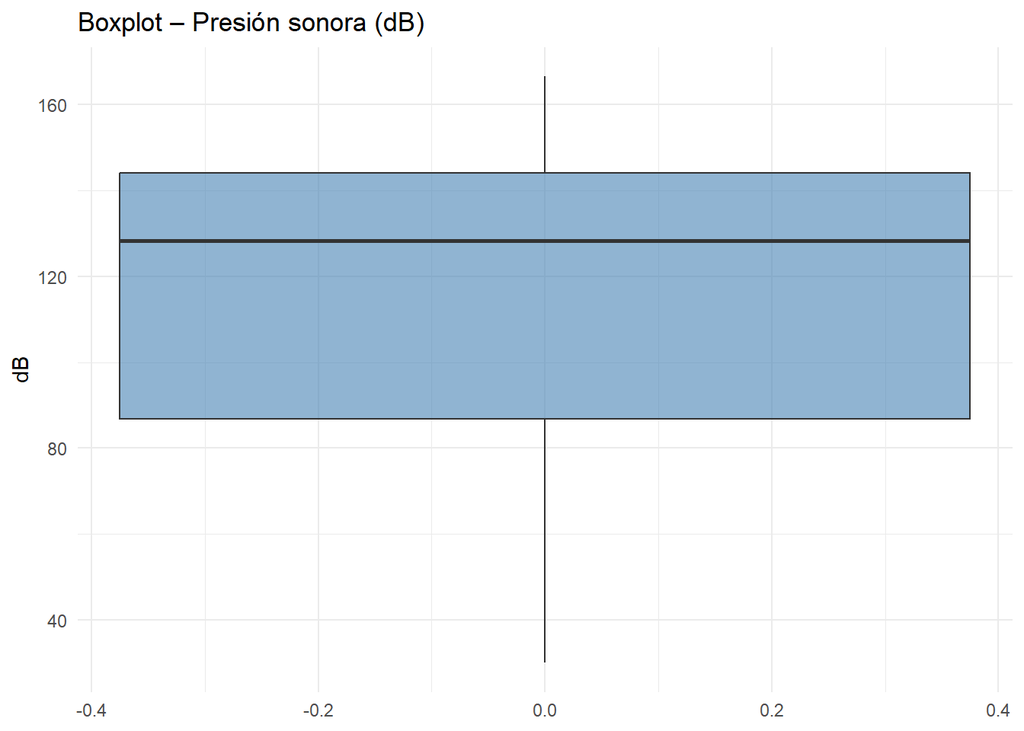

```r
# Boxplot
ggplot(DF_Final, aes(y = `Nivel de presión sonora (dB)`)) +
  geom_boxplot(fill = "steelblue", alpha = 0.6) +
  labs(title = "Boxplot – Presión sonora (dB)", y = "dB") +
  theme_minimal()
```

El histograma revela comportamiento bimodal: un grupo en torno a los 50 dB y otro más numeroso alrededor de los 130 dB. Esto explica por qué la media cae en una zona de baja frecuencia. El boxplot muestra caja amplia sin atípicos.

### Variable 2: Nivel de iluminancia (lux) Cuantitativa continua

```r
Q1_lux <- quantile(DF_Final$`Nivel de iluminancia`, 0.25, na.rm = TRUE)
Q3_lux <- quantile(DF_Final$`Nivel de iluminancia`, 0.75, na.rm = TRUE)

tabla_iluminancia <- data.frame(
  Descriptor = c(
    "Media", "Mediana", "Desviación estándar",
    "Coeficiente de variación", "Q1", "Q3",
    "Rango intercuartílico (IQR)", "Mínimo", "Máximo"
  ),
  Valor = c(
    round(mean(DF_Final$`Nivel de iluminancia`, na.rm = TRUE), 2),
    round(median(DF_Final$`Nivel de iluminancia`, na.rm = TRUE), 2),
    round(sd(DF_Final$`Nivel de iluminancia`, na.rm = TRUE), 2),
    round(sd(DF_Final$`Nivel de iluminancia`, na.rm = TRUE) /
            mean(DF_Final$`Nivel de iluminancia`, na.rm = TRUE), 2),
    round(Q1_lux, 2),
    round(Q3_lux, 2),
    round(Q3_lux - Q1_lux, 2),
    round(min(DF_Final$`Nivel de iluminancia`, na.rm = TRUE), 2),
    round(max(DF_Final$`Nivel de iluminancia`, na.rm = TRUE), 2)
  )
)

tabla_iluminancia
```

```
                   Descriptor   Valor
1                       Media  326.89
2                     Mediana  234.56
3         Desviación estándar  385.76
4    Coeficiente de variación    1.18
5                          Q1  103.25
6                          Q3  382.34
7 Rango intercuartílico (IQR)  279.09
8                      Mínimo    0.07
9                      Máximo 1978.87
```

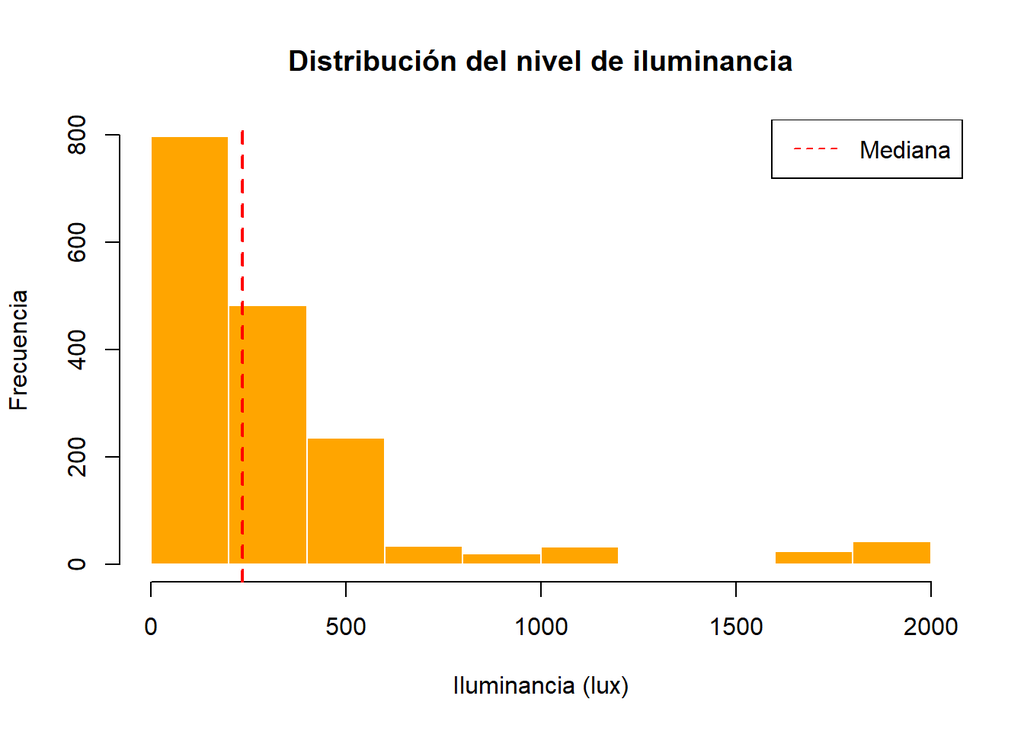

```r
# Histograma
hist(
  na.omit(DF_Final$`Nivel de iluminancia`),
  main   = "Distribución del nivel de iluminancia",
  xlab   = "Iluminancia (lux)",
  ylab   = "Frecuencia",
  col    = "orange",
  border = "white"
)
abline(v = median(na.omit(DF_Final$`Nivel de iluminancia`)),
       col = "red", lty = 2, lwd = 2)
legend("topright", legend = "Mediana", col = "red", lty = 2)
```

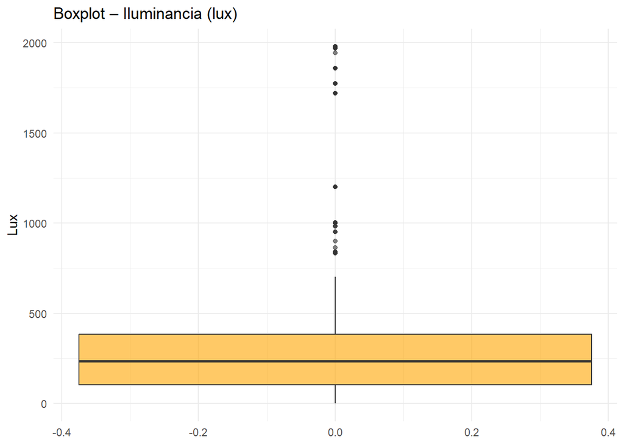

```r
# Boxplot
ggplot(DF_Final, aes(y = `Nivel de iluminancia`)) +
  geom_boxplot(fill = "orange", alpha = 0.6) +
  labs(title = "Boxplot – Iluminancia (lux)", y = "Lux") +
  theme_minimal()
```

### Variable 3: Nivel de facilidad para estudiar Cualitativa ordinal

```r
tabla_facil <- DF_Final %>%
  count(`Nivel de facilidad para estudiar en el ambiente`) %>%
  rename(`Frecuencia absoluta` = n) %>%
  mutate(
    `Frecuencia acumulada` = cumsum(`Frecuencia absoluta`),
    Porcentaje = round(`Frecuencia absoluta` /
                          sum(`Frecuencia absoluta`) * 100, 2)
  )

tabla_facil
```

```
# A tibble: 5 × 4
  Nivel de facilidad p…¹ `Frecuencia absoluta` `Frecuencia acumulada` Porcentaje
  <ord>                                  <int>                  <int>      <dbl>
1 1                                        126                    126       7.55
2 2                                        206                    332      12.3
3 3                                        540                    872      32.4
4 4                                        499                   1371      29.9
5 5                                        298                   1669      17.9
# ℹ abbreviated name: ¹`Nivel de facilidad para estudiar en el ambiente`
```

```r
cat("Mediana:", median(as.integer(DF_Final$`Nivel de facilidad para estudiar en el ambiente`), na.rm = TRUE), "\n")
```

```
Mediana: 3
```

```r
cat("Moda:  ", names(sort(table(DF_Final$`Nivel de facilidad para estudiar en el ambiente`), decreasing = TRUE))[1], "\n")
```

```
Moda:   3
```

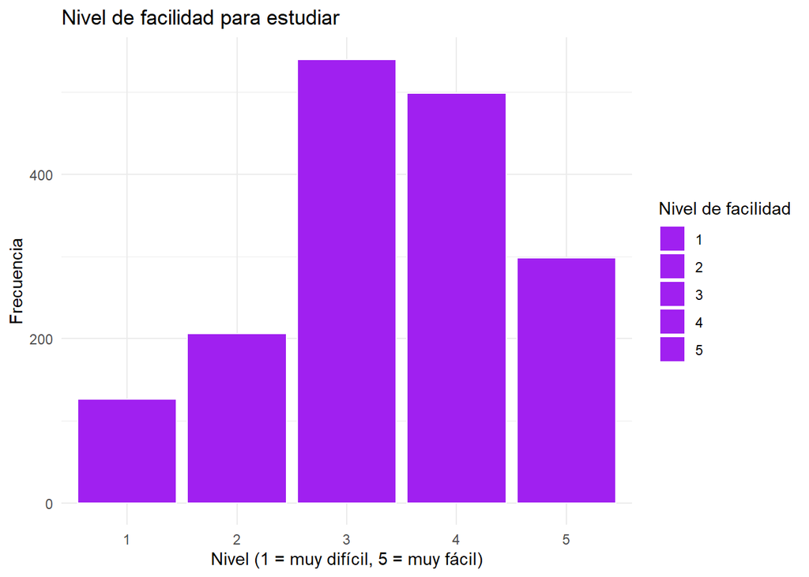

```r
# grafico de barras
ggplot(DF_Final, aes(x = `Nivel de facilidad para estudiar en el ambiente`, fill = `Nivel de facilidad para estudiar en el ambiente`)) +
  geom_bar(color = "white") +
  scale_fill_manual(values = rep("purple", 5)) +
  labs(title = "Nivel de facilidad para estudiar",
       x = "Nivel (1 = muy difícil, 5 = muy fácil)",
       y = "Frecuencia",
       fill = "Nivel de facilidad") +
  theme_minimal()
```

### Variable 4: Tipo de distractores Cualitativa nominal

```r
tabla_dist <- DF_Final %>%
  count(`Tipo de distractores no relacionados con su propósito`) %>%
  rename(`Frecuencia absoluta` = n) %>%
  mutate(
    Porcentaje = round(
      `Frecuencia absoluta` /
      sum(`Frecuencia absoluta`) * 100,
      2
    )
  )

tabla_dist
```

```
# A tibble: 4 × 3
  Tipo de distractores no relacionados con su…¹ `Frecuencia absoluta` Porcentaje
  <fct>                                                         <int>      <dbl>
1 Auditivos                                                       838      50.2
2 Visuales                                                        331      19.8
3 Tecnológicos                                                    494      29.6
4 Olfativos                                                         6       0.36
# ℹ abbreviated name: ¹`Tipo de distractores no relacionados con su propósito`
```

```r
cat("Moda:", as.character(tabla_dist$`Tipo de distractores no relacionados con su propósito`[1]), "\n")
```

```
Moda: Auditivos
```

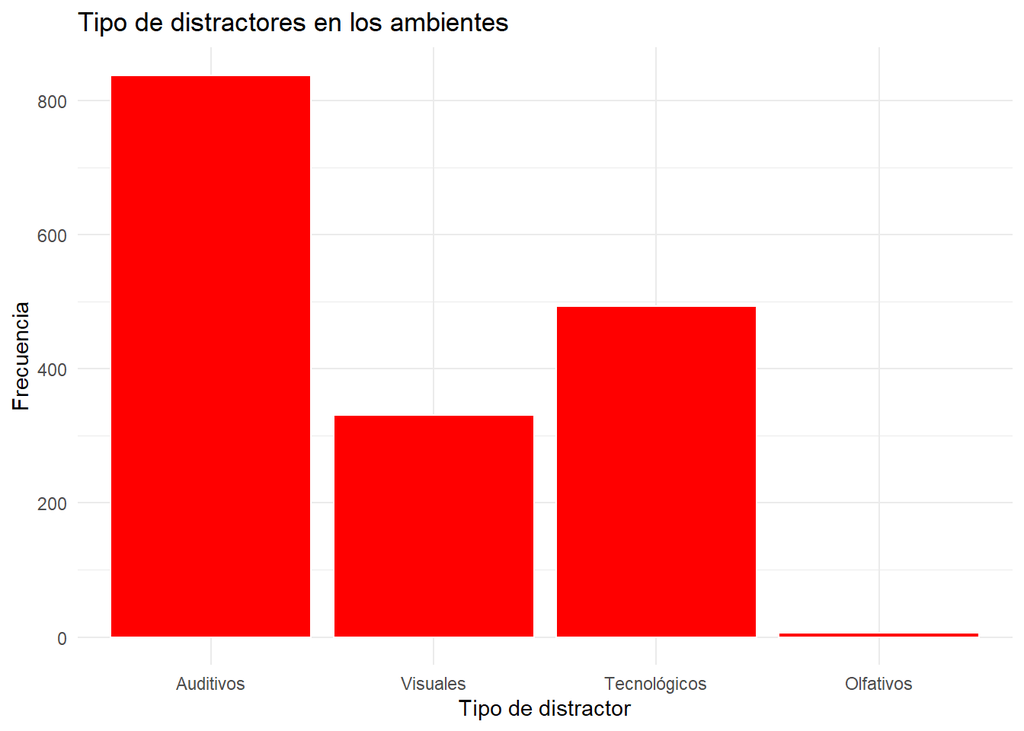

```r
ggplot(DF_Final, aes(x = `Tipo de distractores no relacionados con su propósito`)) +
  geom_bar(fill = "red", color = "white") +
  labs(
    title = "Tipo de distractores en los ambientes",
    x = "Tipo de distractor",
    y = "Frecuencia"
  ) +
  theme_minimal()
```

> **Nota metodológica:** La categoría **Olfativos** representa menos del 1% de las observaciones, lo que limita cualquier análisis comparativo para esa categoría.

## III.2 Análisis de interacción

### Par de variables numéricas (OE1): Ruido vs. Iluminancia

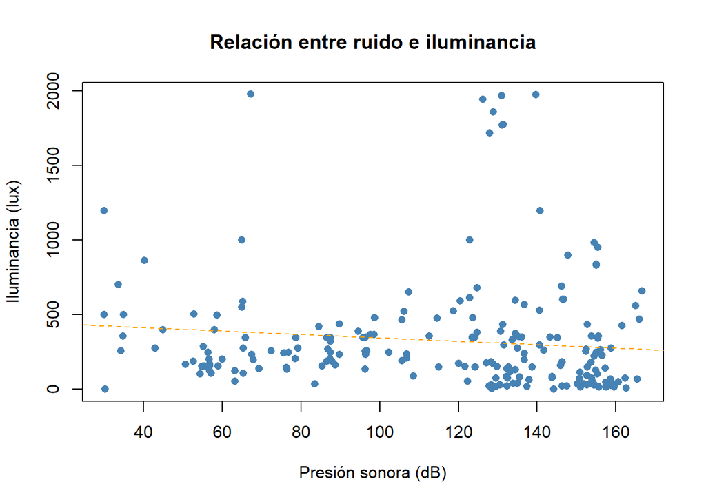

```r
plot(
  x = DF_Final$`Nivel de presión sonora (dB)`,
  y = DF_Final$`Nivel de iluminancia`,
  main = "Relación entre ruido e iluminancia",
  xlab = "Presión sonora (dB)",
  ylab = "Iluminancia (lux)",
  pch = 16,
  col = "steelblue"
)
abline(lm(`Nivel de iluminancia` ~ `Nivel de presión sonora (dB)`,data = DF_Final),col = "orange", lty = 2)
```

> **Interpretación:** La dirección y forma de la línea de tendencia indican la relación lineal: una pendiente pronunciada señala codependencia sistemática entre ambas variables, mientras que una pendiente plana indica que son independientes.

### Par de variables numéricas y categórica (OE1): Ruido según Fuente de Luz

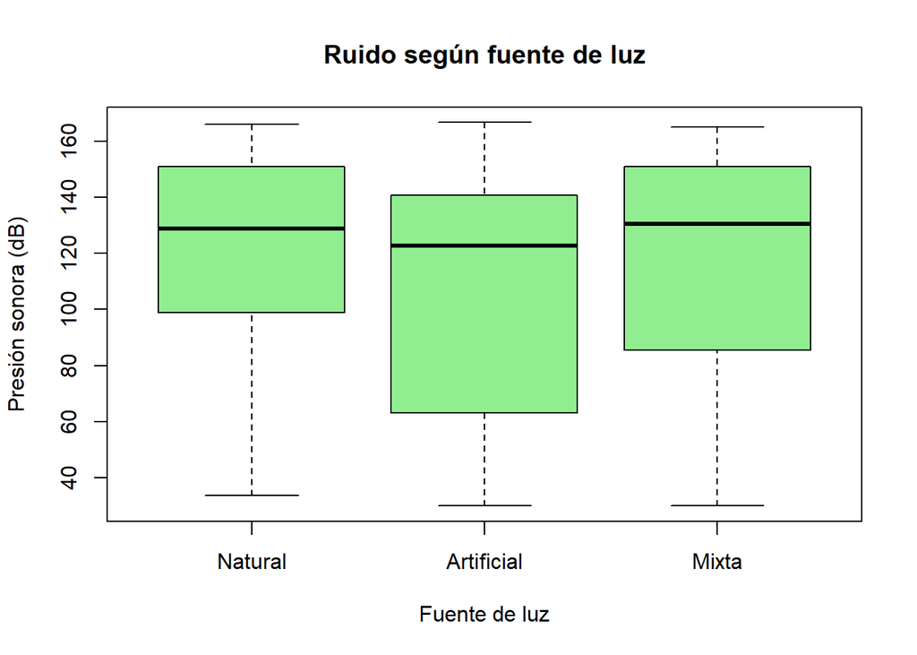

```r
boxplot(
  `Nivel de presión sonora (dB)` ~ `Fuente de luz`,
  data  = DF_Final,
  main  = "Ruido según fuente de luz",
  xlab  = "Fuente de luz",
  ylab  = "Presión sonora (dB)",
  col   = "lightgreen"
)
```

### Variable numérica y categórica (OE1): Iluminancia según Facilidad para Estudiar

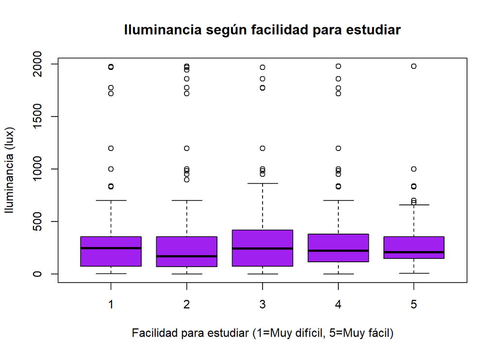

```r
boxplot(
  `Nivel de iluminancia` ~ `Nivel de facilidad para estudiar en el ambiente`,
  data  = DF_Final,
  main= "Iluminancia según facilidad para estudiar",
  xlab  = "Facilidad para estudiar (1=Muy difícil, 5=Muy fácil)",
  ylab  = "Iluminancia (lux)",
  col   = "purple"
)
```

### Variable numérica y categórica (OE1): Nivel de presión sonora según Propósito en la comunidad

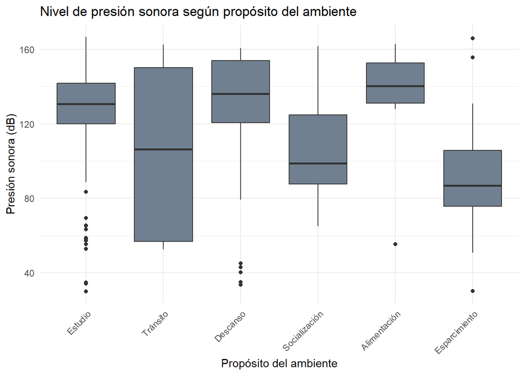

```r
ggplot(DF_Final, aes(x = `Propósito en la comunidad`,
                     y = `Nivel de presión sonora (dB)`)) +
  geom_boxplot(fill = "slategray") +
  labs(
    title = "Nivel de presión sonora según propósito del ambiente",
    x = "Propósito del ambiente",
    y = "Presión sonora (dB)"
  ) +
  theme_minimal() +
  theme(axis.text.x = element_text(angle = 45, hjust = 1))
```

### Par de variables categóricas (OE2): Comodidad según Fuente de Ruido

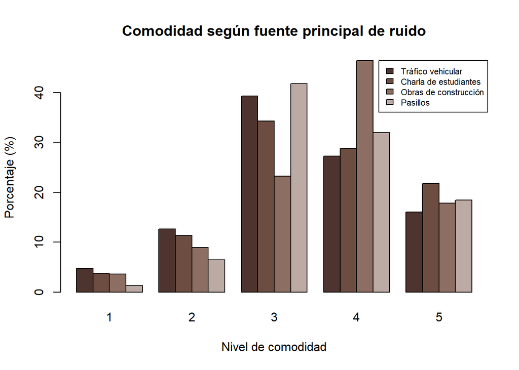

```r
tabla_o2 <- table(
  DF_Final$`Fuente principal de ruido`,
  DF_Final$`Nivel de comodidad`
)

colores_marron <- c(
  "#4E342E",
  "#6D4C41",
  "#8D6E63",
  "#BCAAA4"
)

barplot(
  prop.table(tabla_o2, margin = 1) * 100,
  beside = TRUE,
  main = "Comodidad según fuente principal de ruido",
  xlab = "Nivel de comodidad",
  ylab = "Porcentaje (%)",
  col = colores_marron,
  legend = rownames(tabla_o2),
  args.legend = list(x = "topright", cex = 0.7)
)
```

### Par de variables categóricas (OE2): Frecuencia de Uso según Tipo de Distractores

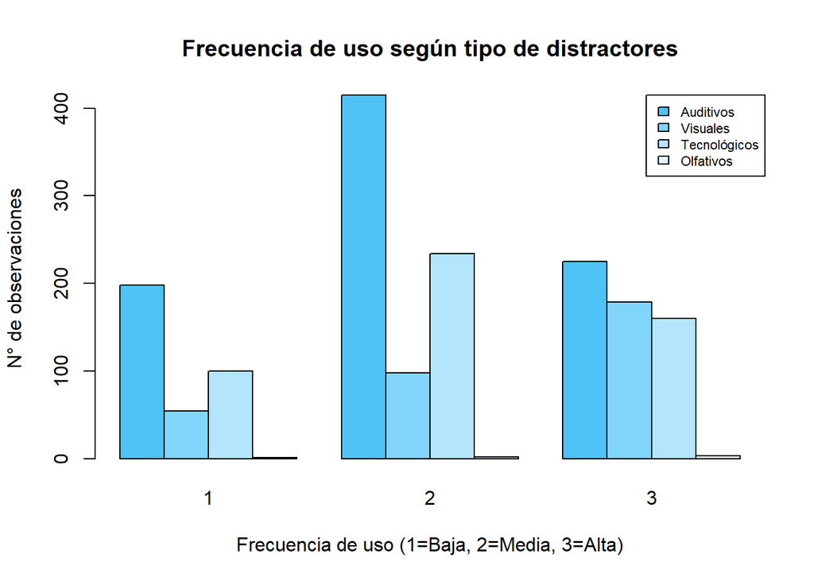

```r
tabla_o2b <- table(
  DF_Final$`Tipo de distractores no relacionados con su propósito`,
  DF_Final$`Frecuencia de uso del ambiente`
)

colores_celeste <- c(
  "#4FC3F7",
  "#81D4FA",
  "#B3E5FC",
  "#E1F5FE"
)

barplot(
  tabla_o2b,
  beside = TRUE,
  main = "Frecuencia de uso según tipo de distractores",
  xlab = "Frecuencia de uso (1=Baja, 2=Media, 3=Alta)",
  ylab = "N° de observaciones",
  col = colores_celeste,
  legend = rownames(tabla_o2b),
  args.legend = list(x = "topright", cex = 0.7)
)
```

### Variable numérica y categórica (OE3): N° de Personas según Facilidad para Estudiar

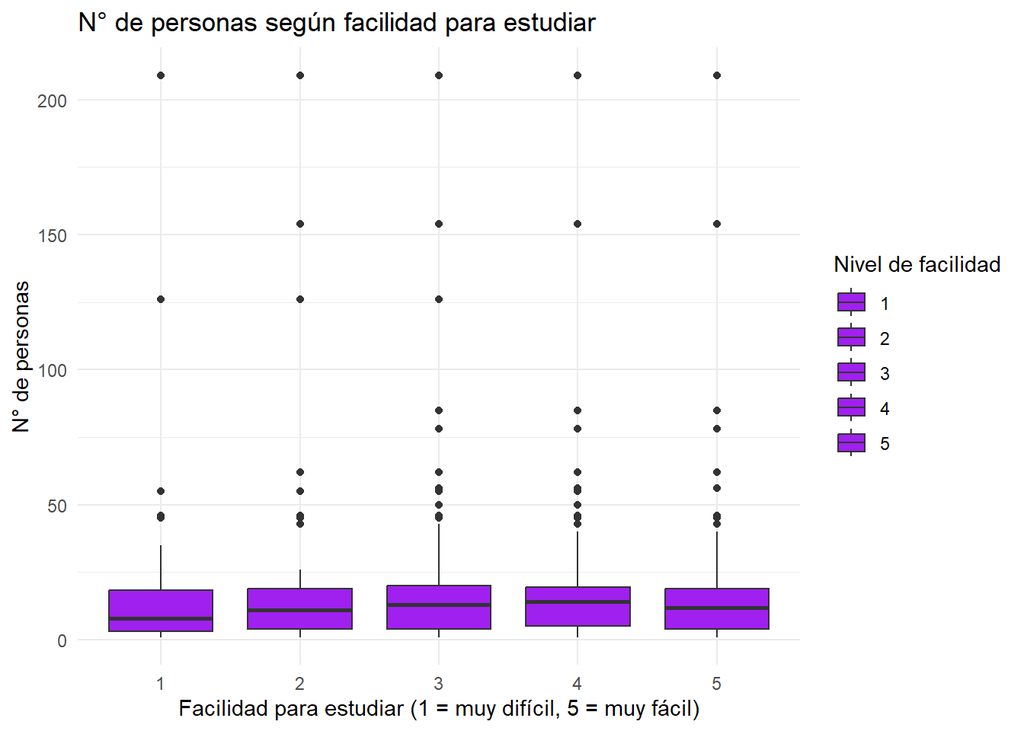

```r
ggplot(DF_Final, aes(x = `Nivel de facilidad para estudiar en el ambiente`,y = `N° de personas presentes`,fill = `Nivel de facilidad para estudiar en el ambiente`)) +
  geom_boxplot() +
  scale_fill_manual(values = rep("purple", 5)) +
  labs(title = "N° de personas según facilidad para estudiar",
       x = "Facilidad para estudiar (1 = muy difícil, 5 = muy fácil)",
       y = "N° de personas",
       fill = "Nivel de facilidad") +
  theme_minimal()
```

### Variable numérica y categórica (OE3): Tomacorrientes según Avance Académico

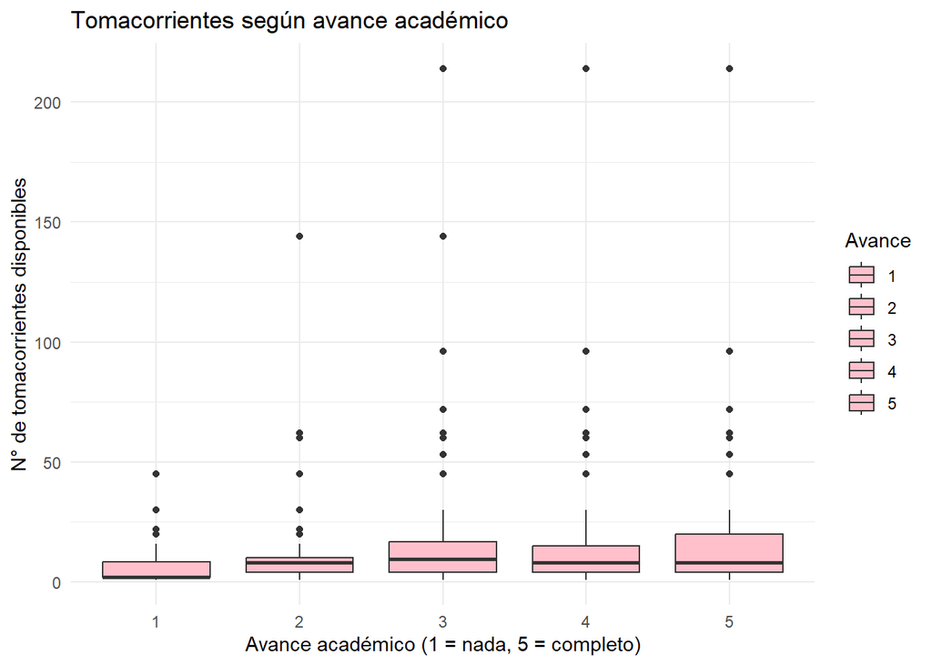

```r
ggplot(DF_Final, aes(x = `Avance de actividades curriculares`,y = `N° de tomacorrientes disponibles`, fill = `Avance de actividades curriculares`)) +
  geom_boxplot() + scale_fill_manual(values = rep("pink", 5)) +
  labs(title = "Tomacorrientes según avance académico",
       x = "Avance académico (1 = nada, 5 = completo)",
       y = "N° de tomacorrientes disponibles",
       fill = "Avance") +
  theme_minimal()
```

# IV. Análisis probabilístico

## IV.1 Probabilidad empírica

### IV.1.1 Probabilidad empírica – Nivel de presión sonora (dB)

La primera variable seleccionada es el **Nivel de presión sonora (dB)**, variable cuantitativa continua vinculada al OE1 y OE2.

Experimento aleatorio (EA_1): Seleccionar una medición de presión sonora al azar y observar la categoría acústica correspondiente.

Espacio de resultados teórico:
$$\Omega_1 = \{\text{Bajo},\ \text{Moderado},\ \text{Alto},\ \text{Muy alto}\}$$
Eventos atómicos: - e1 **(Bajo):** Observar categoría **Bajo** (30–70 dB). - e2 **(Moderado):** Observar categoría **Moderado** (70–90 dB). - e3 **(Alto):** Observar categoría **Alto** (90–120 dB). - e4 **(Muy alto):** Observar categoría **Muy alto** (≥120 dB).

```r
dB <- na.omit(DF_Final$`Nivel de presión sonora (dB)`)

presion_cat <- cut(dB,
                   breaks = c(30, 70, 90, 120, Inf),
                   labels = c("Bajo", "Moderado", "Alto", "Muy alto"),
                   right  = FALSE)

#Probabilidades empíricas
freq_abs <- table(presion_cat)
freq_rel <- prop.table(freq_abs)

# Tabla de resultados
tabla_empirica_dB <- data.frame(
  `Evento atómico` = names(freq_abs),
  `Frecuencia absoluta` = as.integer(freq_abs),
  `Probabilidad empírica` = round(as.numeric(freq_rel), 4),
  check.names = FALSE
)

print(tabla_empirica_dB)
```

```
  Evento atómico Frecuencia absoluta Probabilidad empírica
1           Bajo                 320                0.1917
2       Moderado                 166                0.0995
3           Alto                 171                0.1025
4       Muy alto                1012                0.6064
```

```r
cat('Comprobación: La suma de las probabilidades es igual a', sum(freq_rel))
```

```
Comprobación: La suma de las probabilidades es igual a 1
```

### IV.1.2 Probabilidad empírica – Nivel de facilidad para estudiar

La segunda variable es el **Nivel de facilidad para estudiar en el ambiente**, ordinal con cinco niveles, vinculada al OE1 y OE3.

Experimento aleatorio (EA_2): Seleccionar un registro de encuesta al azar y observar el nivel de facilidad para estudiar reportado.

Espacio de resultados teórico:

$$\Omega_2 = \{\text{Muy difícil},\ \text{Difícil},\ \text{Regular},\ \text{Fácil},\ \text{Muy fácil}\}$$

Eventos atómicos: - e1 **(Muy difícil):** Observar nivel **Muy difícil** (Nivel 1). - e2 **(Difícil):** Observar nivel **Difícil** (Nivel 2). - e3 **(Regular):** Observar nivel **Regular** (Nivel 3). - e4 **(Fácil):** Observar nivel **Fácil** (Nivel 4). - e5 **(Muy fácil):** Observar nivel **Muy fácil** (Nivel 5).

```r
facilidad_vec <- na.omit(as.integer(
  DF_Final$`Nivel de facilidad para estudiar en el ambiente`
))
n_total_fac <- length(facilidad_vec)

facilidad_factor <- factor(
  facilidad_vec,
  levels = 1:5,
  labels = c("Muy difícil", "Difícil", "Regular", "Fácil", "Muy fácil")
)

freq_abs_fac <- table(facilidad_factor)
freq_rel_fac <- prop.table(freq_abs_fac)

tabla_empirica_fac <- data.frame(
  `Evento atómico`       = names(freq_abs_fac),
  `Frecuencia absoluta`  = as.integer(freq_abs_fac),
  `Probabilidad empírica` = round(as.numeric(freq_rel_fac), 4),
  check.names = FALSE
)

print(tabla_empirica_fac)
```

```
  Evento atómico Frecuencia absoluta Probabilidad empírica
1    Muy difícil                 126                0.0755
2        Difícil                 206                0.1234
3        Regular                 540                0.3235
4          Fácil                 499                0.2990
5      Muy fácil                 298                0.1786
```

```r
cat('Comprobación: La suma de las probabilidades es igual a', sum(freq_rel_fac))
```

```
Comprobación: La suma de las probabilidades es igual a 1
```

Regular (Nivel 3) es el más probable. Los niveles 4 y 5 acumulan ~48% y los niveles 1-2 el ~20%, confirmando que las condiciones desfavorables no son las más frecuentes.

## IV.2 Probabilidad condicional e independencia

### Selección de Eventos

Este análisis trabaja directamente con eventos definidos por los valores de las dos variables principales.

**Evento 1 (E1):** Seleccionar un registro donde la presión sonora sea **Muy alto** (≥120 dB).

**Evento 2 (E2):** Seleccionar un registro donde el nivel de facilidad para estudiar sea **Muy difícil** (Nivel 1).

### Construcción de la Tabla de Contingencia

```r
# Limpieza interna para asegurar que trabajamos con registros completos en ambas columnas

data_prob <- DF_Final %>%
  filter(!is.na(`Nivel de presión sonora (dB)`),
         !is.na(`Nivel de facilidad para estudiar en el ambiente`)) %>%
  mutate(
    cat_dB  = cut(`Nivel de presión sonora (dB)`,
                  breaks = c(30, 70, 90, 120, Inf),
                  labels = c("Bajo", "Moderado", "Alto", "Muy alto"),
                  right  = FALSE),
    niv_fac = as.integer(`Nivel de facilidad para estudiar en el ambiente`)
  )

n_total_prob <- nrow(data_prob)

# Construcción de la tabla de contingencia básica
tabla_contingencia <- table(
  `Nivel de presión sonora` = data_prob$cat_dB,
  `Facilidad para estudiar` = data_prob$niv_fac
)

# Tabla con totales marginales
cat(" Tabla de contingencia (frecuencias absolutas) ")
```

```
 Tabla de contingencia (frecuencias absolutas)
```

```r
print(addmargins(tabla_contingencia))
```

```
                       Facilidad para estudiar
Nivel de presión sonora    1    2    3    4    5  Sum
               Bajo       32   39   79  105   65  320
               Moderado    3   14   56   57   36  166
               Alto        0   11   67   54   39  171
               Muy alto   91  142  338  283  158 1012
               Sum       126  206  540  499  298 1669
```

## Prueba de Independencia de Eventos

Dos eventos $E_1$ y $E_2$ son **independientes**:

$$P(E_1 \cap E_2) = P(E_1) \cdot P(E_2)$$

```r
# Conteos
n_E1           <- sum(data_prob$cat_dB == "Muy alto")
n_E2           <- sum(data_prob$niv_fac == 1)
n_interseccion <- sum(data_prob$cat_dB == "Muy alto" &
                      data_prob$niv_fac == 1)

# Probabilidades
P_E1        <- n_E1 / n_total_prob
P_E2        <- n_E2 / n_total_prob
P_inter     <- n_interseccion / n_total_prob
P_E1_por_E2 <- P_E1 * P_E2

data.frame(
  Expresión = c(
    "P(E1) Muy alto (≥120 dB)",
    "P(E2) Facilidad Muy difícil (Nivel 1)",
    "P(E1 ∩ E2) empírica",
    "P(E1) × P(E2) teórico"
  ),
  Valor = round(c(P_E1, P_E2, P_inter, P_E1_por_E2), 4)
)
```

```
                              Expresión  Valor
1              P(E1) Muy alto (≥120 dB) 0.6064
2 P(E2) Facilidad Muy difícil (Nivel 1) 0.0755
3                   P(E1 ∩ E2) empírica 0.0545
4                 P(E1) × P(E2) teórico 0.0458
```

```r
son_indep <- abs(P_inter - P_E1_por_E2) < 0.0001
cat("\n¿P(E1 ∩ E2) = P(E1) · P(E2) al cuarto decimal?\n")
```

```
¿P(E1 ∩ E2) = P(E1) · P(E2) al cuarto decimal?
```

```r
cat(ifelse(son_indep,
           "Sí: E1 y E2 son INDEPENDIENTES",
           "No: E1 y E2 son DEPENDIENTES"), "\n")
```

```
No: E1 y E2 son DEPENDIENTES
```

## Cálculo de probabilidades y aplicación del Teorema de Bayes

**Probabilidad de la unión:**

$$P(E_1 \cup E_2) = P(E_1) + P(E_2) - P(E_1 \cap E_2)$$

**Probabilidad condicional:**

$$P(E_1 \mid E_2) = \frac{P(E_1 \cap E_2)}{P(E_2)}$$

**Probabilidad condicional sobre el complemento de $E_2$:**

$$P(E_1 \mid E_2^c) = \frac{P(E_1 \cap E_2^c)}{P(E_2^c)}, \qquad P(E_2^c) = 1 - P(E_2)$$

**Teorema de probabilidad total**:

$$P(E_1) = P(E_1 \mid E_2) \cdot P(E_2) + P(E_1 \mid E_2^c) \cdot P(E_2^c)$$

**Teorema de Bayes**:

$$P(E_2 \mid E_1) = \frac{P(E_1 \mid E_2) \cdot P(E_2)}{P(E_1)}$$

```r
# Unión
P_union <- P_E1 + P_E2 - P_inter

# Condicional P(E1 | E2)
P_E1_dado_E2 <- P_inter / P_E2

# Complemento de E2 y P(E1 | E2c)
P_E2c          <- 1 - P_E2
n_E2c          <- sum(data_prob$niv_fac != 1)
n_E1_inter_E2c <- sum(data_prob$cat_dB == "Muy alto" &
                      data_prob$niv_fac != 1)
P_E1_dado_E2c  <- n_E1_inter_E2c / n_E2c

# Probabilidad total de E1
P_E1_total <- P_E1_dado_E2 * P_E2 + P_E1_dado_E2c * P_E2c

# Teorema de Bayes
P_E2_dado_E1_Bayes <- (P_E1_dado_E2 * P_E2) / P_E1_total

data.frame(
  Operación = c(
    "P(E1)  Muy alto (≥120 dB)",
    "P(E2)  Muy difícil (Nivel 1)",
    "P(E1 ∩ E2)",
    "P(E1) × P(E2)",
    "P(E1 ∪ E2)",
    "P(E1 | E2)",
    "P(E1 | E2ᶜ)",
    "P(E1) probabilidad total",
    "P(E2 | E1) Teorema de Bayes"
  ),
  Valor = round(c(
    P_E1,
    P_E2,
    P_inter,
    P_E1_por_E2,
    P_union,
    P_E1_dado_E2,
    P_E1_dado_E2c,
    P_E1_total,
    P_E2_dado_E1_Bayes
  ), 4)
)
```

```
                     Operación  Valor
1    P(E1)  Muy alto (≥120 dB) 0.6064
2 P(E2)  Muy difícil (Nivel 1) 0.0755
3                   P(E1 ∩ E2) 0.0545
4                P(E1) × P(E2) 0.0458
5                   P(E1 ∪ E2) 0.6273
6                   P(E1 | E2) 0.7222
7                  P(E1 | E2ᶜ) 0.5969
8     P(E1) probabilidad total 0.6064
9  P(E2 | E1) Teorema de Bayes 0.0899
```

## IV.3 Variables aleatorias

### IV.3.1 Variables aleatorias discretas

Se construyen dos casos de variables aleatorias discretas a partir de los datos.

#### Caso 1 – Distribución Geométrica

#### Paso 1: Construcción del caso

En los ambientes medidos se registró la **fuente principal de ruido** de cada sesión. Se desea conocer la probabilidad de que la **quinta medición** sea la primera en encontrar un ambiente con **charla de estudiantes** como fuente principal de ruido.

#### Paso 2: Definición de la variable aleatoria discreta y parámetros

Sea $X$ la variable aleatoria: número de mediciones hasta encontrar, por primera vez, un ambiente con charla de estudiantes como fuente principal de ruido. $X \sim \text{Geom}(p)$, donde $p$ es la proporción empírica de ambientes con esa fuente.

```r
# Parámetro p: proporción de ambientes con charla de estudiantes como fuente de ruido
fuente_ruido_validos <- DF_Final %>%
  filter(!is.na(`Fuente principal de ruido`))

n_charla <- sum(fuente_ruido_validos$`Fuente principal de ruido` == "Charla de estudiantes")
n_total_ruido <- nrow(fuente_ruido_validos)

p_charla <- n_charla / n_total_ruido

cat("n total mediciones con fuente de ruido registrada:", n_total_ruido, "\n")
```

```
n total mediciones con fuente de ruido registrada: 1669
```

```r
cat("n ambientes con charla de estudiantes:", n_charla, "\n")
```

```
n ambientes con charla de estudiantes: 872
```

```r
cat("p (probabilidad de éxito) =", round(p_charla, 2), "\n")
```

```
p (probabilidad de éxito) = 0.52
```

$$X \sim \text{Geom}(p = 0.52)$$

#### Paso 3: Descripción de la distribución teórica

$$P(X = k) = (1 - p)^{k-1} \cdot p, \quad k = 1, 2, 3, \ldots, n$$

```r
#cuenta el número de **fracasos** antes del primer éxito, por lo que para calcular P(X = k) (número de intentos hasta el primer éxito) se debe usar dgeom(k - 1, p)

# Distribución puntual y acumulada  Geométrica
p_geom <- p_charla
n_max  <- n_total_ruido   # tamaño de la muestra

k_vals <- 1:n_max

# Probabilidades puntuales: P(X = k) = dgeom(k-1, p)
probs_geom <- dgeom(k_vals - 1, prob = p_geom)

# Acumulada izquierda: P(X <= k) = pgeom(k-1, p, lower.tail = TRUE)
acum_izq <- pgeom(k_vals - 1, prob = p_geom, lower.tail = TRUE)

# Acumulada derecha: P(X > k) = pgeom(k-1, p, lower.tail = FALSE)
acum_der <- pgeom(k_vals - 1, prob = p_geom, lower.tail = FALSE)

df_geom <- data.frame(
  k = k_vals,
  P_puntual  = round(probs_geom, 6),
  P_acum_izq  = round(acum_izq,   6),
  P_acum_der = round(acum_der,   6)
)

# Mostrar los primeros 15 valores
head(df_geom, 15)
```

```
    k P_puntual P_acum_izq P_acum_der
1   1  0.522469   0.522469   0.477531
2   2  0.249495   0.771964   0.228036
3   3  0.119142   0.891105   0.108895
4   4  0.056894   0.947999   0.052001
5   5  0.027169   0.975168   0.024832
6   6  0.012974   0.988142   0.011858
7   7  0.006195   0.994337   0.005663
8   8  0.002959   0.997296   0.002704
9   9  0.001413   0.998709   0.001291
10 10  0.000675   0.999383   0.000617
11 11  0.000322   0.999706   0.000294
12 12  0.000154   0.999859   0.000141
13 13  0.000073   0.999933   0.000067
14 14  0.000035   0.999968   0.000032
15 15  0.000017   0.999985   0.000015
```

**Gráfico de distribución puntual**

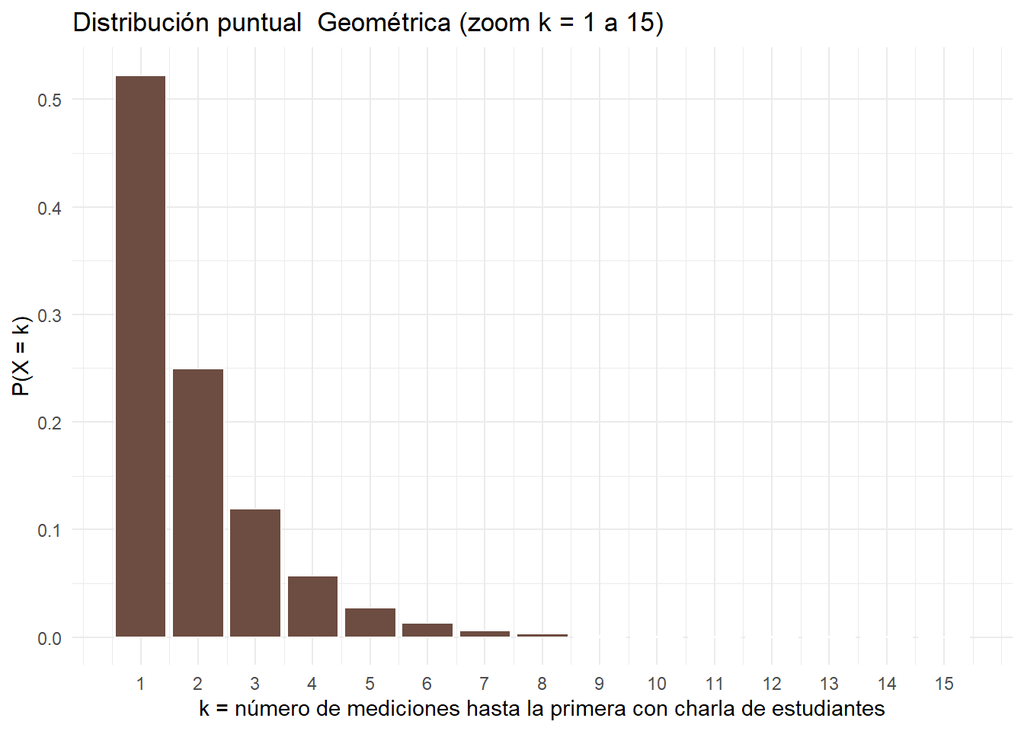

```r
# Zoom: región donde la probabilidad es visible (primeros 15 intentos)
k_zoom <- 1:15

ggplot(data.frame(k = k_zoom, prob = dgeom(k_zoom - 1, prob = p_geom)),
       aes(x = k, y = prob)) +
  geom_bar(stat = "identity", fill = "#6D4C41", color = "white") +
  labs(
    title = "Distribución puntual  Geométrica (zoom k = 1 a 15)",
    x     = "k = número de mediciones hasta la primera con charla de estudiantes",
    y     = "P(X = k)"
  ) +
  scale_x_continuous(breaks = k_zoom) +
  theme_minimal()
```

**Gráfico de distribución acumulada hacia la izquierda:**

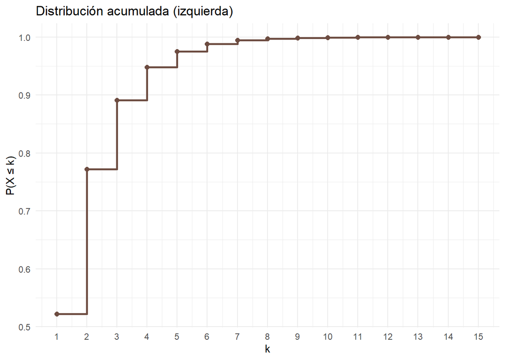

```r
ggplot(data.frame(k = k_zoom, acum = pgeom(k_zoom - 1, prob = p_geom, lower.tail = TRUE)),
       aes(x = k, y = acum)) +
  geom_step(color = "#6D4C41", size = 1) +
  geom_point(color = "#6D4C41", size = 2) +
  labs(
    title = "Distribución acumulada (izquierda)",
    x     = "k",
    y     = "P(X ≤ k)"
  ) +
  scale_x_continuous(breaks = k_zoom) +
  theme_minimal()
```

**Gráfico de distribución acumulada hacia la derecha:**

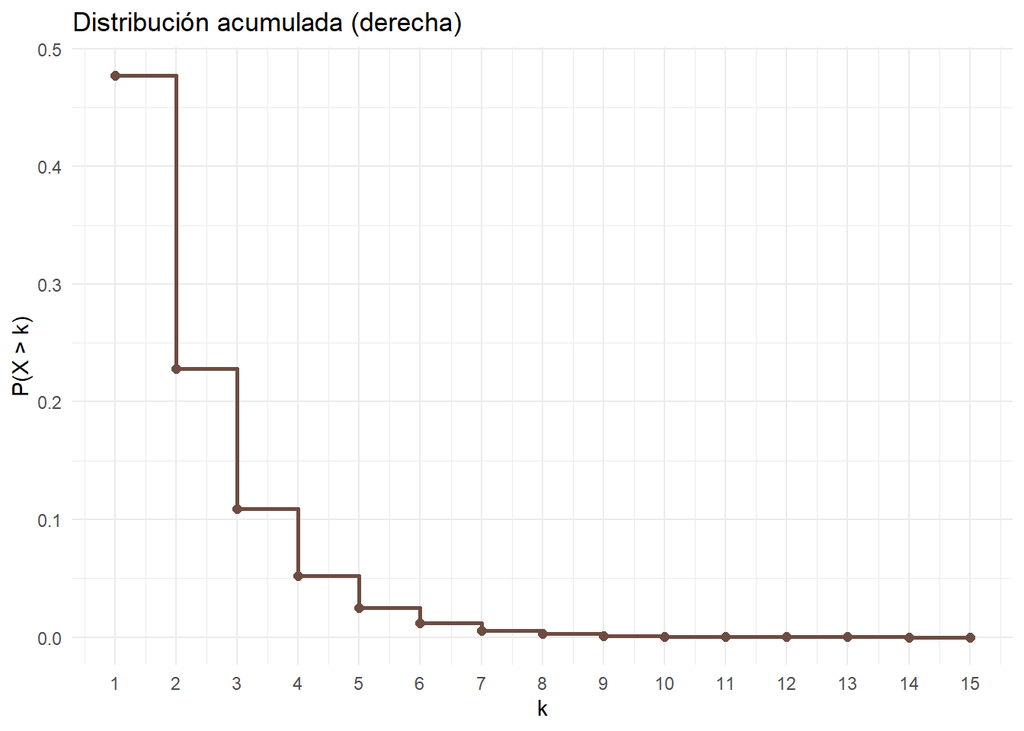

```r
ggplot(data.frame(k = k_zoom, acum = pgeom(k_zoom - 1, prob = p_geom, lower.tail = FALSE)),
       aes(x = k, y = acum)) +
  geom_step(color = "#6D4C41", size = 1) +
  geom_point(color = "#6D4C41", size = 2) +
  labs(
    title = "Distribución acumulada (derecha)",
    x     = "k",
    y     = "P(X > k)"
  ) +
  scale_x_continuous(breaks = k_zoom) +
  theme_minimal()
```

#### Paso 4: Propiedades de la distribución teórica

```r
E_geom   <- 1 / p_geom
Var_geom <- (1 - p_geom) / p_geom^2
SD_geom  <- sqrt(Var_geom)

data.frame(
  Propiedad = c("Esperanza: E(X)", "Varianza: Var(X)", "Desviación estándar: SD(X)"),
  Valor     = round(c(E_geom, Var_geom, SD_geom), 4)
)
```

```
                   Propiedad  Valor
1            Esperanza: E(X) 1.9140
2           Varianza: Var(X) 1.7494
3 Desviación estándar: SD(X) 1.3226
```

#### Paso 5: Respuesta al caso

**Pregunta:** ¿Cuál es la probabilidad de que la **quinta medición** sea la primera en encontrar un ambiente con charla de estudiantes como fuente principal de ruido?

$$P(X = 5) = (1 - p)^{4} \cdot p$$

```r
# Responder el caso: P(X = 5)
p_caso1_puntual <- dgeom(4, prob = p_geom)   # 4 fracasos antes del primer éxito

cat("P(X = 5) =", round(p_caso1_puntual, 6), "\n")
```

```
P(X = 5) = 0.027169
```

Interpretación: Existe una probabilidad de aproximadamente 2.71% de que exactamente la quinta medición sea la primera en encontrar un ambiente con charla de estudiantes.

##### Paso 6: Ejemplo de distribución acumulada

**Pregunta:** ¿Cuál es la probabilidad de que se necesiten **menos de 3 mediciones** para encontrar el primer ambiente con charla de estudiantes?

$$P(X < 3) = P(X \le 2) = \sum_{k=1}^{2} (1-p)^{k-1} \cdot p$$

```r
# P(X < 3) = P(X <= 2) usando cola izquierda
p_caso1_acum <- pgeom(1, prob = p_geom, lower.tail = TRUE)   # 1 fracaso máximo

cat("P(X < 3) = P(X ≤ 2) =", round(p_caso1_acum, 6), "\n")
```

```
P(X < 3) = P(X ≤ 2) = 0.771964
```

**Interpretación:** Existe un **77.19%** de probabilidad de que se necesiten menos de 3 mediciones para encontrar por primera vez un ambiente con charla de estudiantes como fuente principal de ruido.

#### Caso 2 – Distribución Binomial

##### Paso 1: Construcción del caso

Cada estudiante encuestado reporta si le resulta **fácil o muy fácil** (niveles 4 o 5) estudiar en el ambiente. Se seleccionan **15 registros de encuesta al azar** y se desea conocer cuántos de ellos reportan una facilidad alta para estudiar.

#### Paso 2: Definición de la variable aleatoria discreta y parámetros

Sea $X$ la variable aleatoria discreta definida como:

Se a X, número de estudiantes, entre 15 seleccionados al azar de la muestra efectiva, que reportan que el nivel de facilidad para estudiar en el ambiente es Fácil o Muy fácil.

Esta variable sigue una distribución **Binomial**:

$$X \sim \text{Binom}(n = 15,\ p)$$

```r
# Parámetro p: proporción de registros con facilidad >= 4
facilidad_vec <- na.omit(as.integer(
  DF_Final$`Nivel de facilidad para estudiar en el ambiente`
))

n_facil_alto  <- sum(facilidad_vec >= 4)
n_total_facil <- length(facilidad_vec)
p_facil       <- n_facil_alto / n_total_facil

cat("n total registros de facilidad:", n_total_facil, "\n")
```

```
n total registros de facilidad: 1669
```

```r
cat("n con facilidad >= 4 (Fácil o Muy fácil):", n_facil_alto, "\n")
```

```
n con facilidad >= 4 (Fácil o Muy fácil): 797
```

```r
cat("p (probabilidad de éxito) =", round(p_facil, 4), "\n")
```

```
p (probabilidad de éxito) = 0.4775
```

$$X \sim \text{Binom}(n = 15,\ p = 0.4775)$$